# CyteType Report

CyteType Report

## CyteType Report

View Online

Completed

November 14, 2025 at 3:30 AM

TITLE: My scRNA-seq analysis of axolotl limb regeneration

RUN_LABEL: immune_analysis

EXPERIMENT_NAME: inDrops_axo

DOI: https://doi.org/10.1038/s41467-018-07604-0

GEO_ACCESSION: GSE121737

### Dataset Context

The dataset comprises subsetted primary immune cells from the axolotl (Ambystoma mexicanum), a salamander renowned for its regenerative capabilities, specifically derived from a time course of limb regeneration. These cells originate from hematopoietic and immune tissues, such as blood, spleen, or lymphoid organs, where the normal cellular composition includes diverse leukocyte populations expressing pan-leukocyte markers like CD45 (PTPRC) and other immune-specific proteins involved in antigen presentation, actin dynamics, and cell motility. The cells exhibit states of activation, metabolic activity—evidenced by high glycolytic enzyme expression supporting energy demands—and stress, potentially linked to inflammatory responses or regenerative processes, with indicators like heat shock proteins and interferon gamma receptor suggesting an immune response context. This experimental setup, focusing on primary cells during limb regeneration, highlights the role of immune modulation in tissue repair without implying specific outcomes or unmentioned cell subtypes.

### Tissue Composition Assessment

The dataset primarily consists of immune cell types as expected for primary immune cells from hematopoietic and immune tissues in axolotl limb regeneration, but includes some unexpected non-immune cell types such as fibroblasts and epithelial cells, likely due to the regenerative context involving the limb blastema.

### Notable Findings

- Presence of regeneration-associated macrophages (clusters 3, 6) with specialized lipid efflux and lysosomal functions, highlighting immune contributions to tissue remodeling.
- Axolotl-specific regenerative granulocytes (cluster 11) with immunosuppressive features, suggesting unique adaptations in salamander immunity during regeneration.
- Immune-mimetic fibroblasts (clusters 5, 20) in the limb blastema, indicating a blurring of immune and stromal roles in repair.
- Exhausted/regulatory T cells (cluster 19) expressing PDCD1 and TOX, potentially modulating inflammation in the regenerative niche.
- Erythroid precursors (cluster 10) in an immune-focused dataset, possibly indicating hematopoietic activity tied to regeneration-induced anemia or stress.

1

### Neutrophil-Like Granulocyte

Cathelicidin+ properdin+ lysozyme+ neutrophil-like granulocyte with strong antimicrobial and oxidative burst capacity

Confidence: Moderate

⚠ HETEROGENEOUS

CELL ONTOLOGY TERM

[neutrophil (CL_0000775)](http://purl.obolibrary.org/obo/CL_0000775)

CELL STATE activated, antimicrobial

ORIGINAL LABEL 0

FUNCTIONALLY SIMILAR TO

Macrophage (3)Macrophage (4)Macrophage (6)

DEVELOPMENTALLY RELATED TO

Natural Killer Cell (differentiates_from)

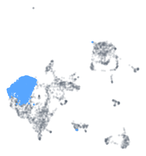

2

### T Cell

CD3E+CD8A+ T cell with tissue-resident features (CXCR6+, ITGAE+) and TCF7/IL7R-mediated stemness preservation in regenerative tissue context

Confidence: High

CELL ONTOLOGY TERM

[CD8-positive, alpha-beta memory T cell (CL_0000909)](http://purl.obolibrary.org/obo/CL_0000909)

CELL STATE tissue-resident, regeneration-adapted

ORIGINAL LABEL 1

FUNCTIONALLY SIMILAR TO

Naive T Cell (12)NK-like T Cell (13)CD8+ T Cell (19)

DEVELOPMENTALLY RELATED TO

Proliferating Thymocyte (differentiates_from)

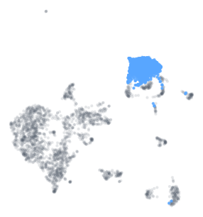

3

### Macrophage

ABCA1+/GPNMB+ lipid-associated regeneration macrophage with extensive lysosomal machinery (CTSD+/CTSB+/CTSL+/LGMN+) and tissue remodeling features

Confidence: High

CELL ONTOLOGY TERM

[lipid-associated macrophage (CL_4033086)](http://purl.obolibrary.org/obo/CL_4033086)

CELL STATE Activated, phagocytic, tissue-remodeling

ORIGINAL LABEL 2

FUNCTIONALLY SIMILAR TO

Neutrophil-Like Granulocyte (1)Macrophage (4)Macrophage (6)

DEVELOPMENTALLY RELATED TO

Natural Killer Cell (differentiates_from)

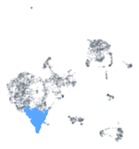

4

### Macrophage

MARCO-positive, cathepsin-rich, C1Q-expressing phagocytic macrophage with lipid metabolism activity

Confidence: High

CELL ONTOLOGY TERM

[splenic marginal zone macrophage (CL_0000872)](http://purl.obolibrary.org/obo/CL_0000872)

CELL STATE activated

ORIGINAL LABEL 3

FUNCTIONALLY SIMILAR TO

Neutrophil-Like Granulocyte (1)Macrophage (3)Macrophage (6)

DEVELOPMENTALLY RELATED TO

Natural Killer Cell (differentiates_from)

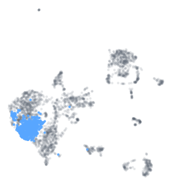

5

### Fibroblast

COL1A1/COL1A2/COL3A1-high ECM-producing fibroblast with ferritin heavy chain enrichment

Confidence: Moderate

⚠ HETEROGENEOUS

CELL ONTOLOGY TERM

[fibroblast (CL_0000057)](http://purl.obolibrary.org/obo/CL_0000057)

CELL STATE activated, ECM-producing

ORIGINAL LABEL 4

FUNCTIONALLY SIMILAR TO

Fibroblast (20)

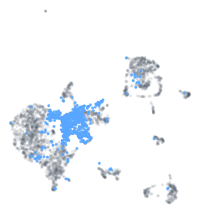

6

### Macrophage

CSF1R+/C1Q+ tissue-resident macrophage with high lysosomal activity (LYZ++/cathepsin-rich), MHC class II antigen presentation capacity (CD74+), and lipid metabolism features (APOE+/ABCA1+)

Confidence: High

CELL ONTOLOGY TERM

[tissue-resident macrophage (CL_0000864)](http://purl.obolibrary.org/obo/CL_0000864)

CELL STATE mature, predominantly non-proliferating with minor proliferative subset (~14-22%)

ORIGINAL LABEL 5

FUNCTIONALLY SIMILAR TO

Neutrophil-Like Granulocyte (1)Macrophage (3)Macrophage (4)

DEVELOPMENTALLY RELATED TO

Natural Killer Cell (differentiates_from)

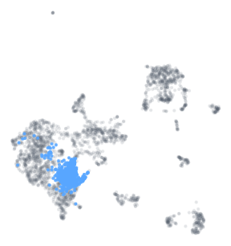

7

### Keratinocyte

EPCAM-positive, S100A13-expressing keratinocyte with Type II cytoskeletal keratin expression and desmosomal junction proteins

Confidence: High

CELL ONTOLOGY TERM

[keratinocyte (CL_0000312)](http://purl.obolibrary.org/obo/CL_0000312)

CELL STATE wound healing

ORIGINAL LABEL 6

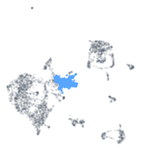

8

### B Cell

CD79A/B-positive, PAX5-expressing B cell with butyrophilin subfamily 2A2-like (LOC138525687), CD209-like lectin (LOC138447708), and siglec-13-like (LOC138449676) surface markers

Confidence: Moderate

CELL ONTOLOGY TERM

[B cell (CL_0000236)](http://purl.obolibrary.org/obo/CL_0000236)

CELL STATE developing

ORIGINAL LABEL 7

DEVELOPMENTALLY RELATED TO

Plasma Cell (differentiates_to)

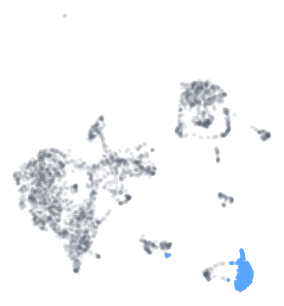

9

### Tissue-Resident Macrophage

CD68+CSF1R+C1Q+ tissue-resident macrophage with TLR2+CD39+IL6R+ activation signature and complement-secreting phagocytic phenotype

Confidence: Moderate

CELL ONTOLOGY TERM

[TREM2-positive macrophage (CL_4047053)](http://purl.obolibrary.org/obo/CL_4047053)

CELL STATE activated, non-proliferative

ORIGINAL LABEL 8

FUNCTIONALLY SIMILAR TO

Neutrophil-Like Granulocyte (1)Macrophage (3)Macrophage (6)

DEVELOPMENTALLY RELATED TO

Natural Killer Cell (differentiates_from)

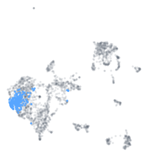

10

### Erythroid Precursor Cell

HEMGN-positive, ALAS2-expressing erythroid precursor with hemoglobin subunit genes (LOC138569677, LOC138567632, LOC138580888) and active heme biosynthesis machinery

Confidence: High

CELL ONTOLOGY TERM

[erythroid progenitor cell (CL_0000038)](http://purl.obolibrary.org/obo/CL_0000038)

CELL STATE proliferating, stressed

ORIGINAL LABEL 9

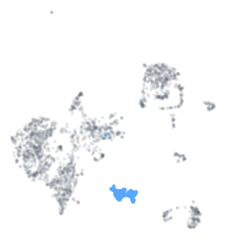

11

### Granulocyte

CEBPE-positive, MMP9-high, chitotriosidase-1-expressing axolotl granulocyte with cathelicidin antimicrobial peptides and regeneration-associated features

Confidence: High

CELL ONTOLOGY TERM

[granulocyte (CL_0000094)](http://purl.obolibrary.org/obo/CL_0000094)

CELL STATE mature, regeneration-associated

ORIGINAL LABEL 10

FUNCTIONALLY SIMILAR TO

Neutrophil-Like Granulocyte (1)Macrophage (3)

DEVELOPMENTALLY RELATED TO

Natural Killer Cell (differentiates_from)

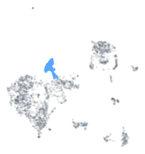

12

### Naive T Cell

TCF7+CCR7+CD28+IL7R+ naive T cell with mixed CD4+/CD8+ populations, showing quiescent phenotype with high translational capacity

Confidence: High

CELL ONTOLOGY TERM

[naive T cell (CL_0000898)](http://purl.obolibrary.org/obo/CL_0000898)

CELL STATE quiescent

ORIGINAL LABEL 11

FUNCTIONALLY SIMILAR TO

T Cell (2)NK-like T Cell (13)CD8+ T Cell (19)

DEVELOPMENTALLY RELATED TO

Proliferating Thymocyte (differentiates_from)

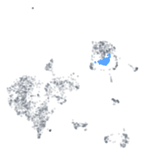

13

### NK-like T Cell

CD7+CD8A+ cytotoxic lymphocyte with killer cell lectin-like receptor expression and tissue-resident features

Confidence: Moderate

⚠ HETEROGENEOUS

CELL ONTOLOGY TERM

[CD8-positive, alpha-beta cytotoxic T cell (CL_0000794)](http://purl.obolibrary.org/obo/CL_0000794)

CELL STATE tissue-resident

ORIGINAL LABEL 12

FUNCTIONALLY SIMILAR TO

T Cell (2)Naive T Cell (12)CD8+ T Cell (19)

DEVELOPMENTALLY RELATED TO

Proliferating Thymocyte (differentiates_from)

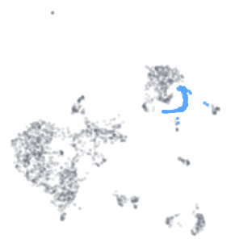

14

### Proliferating Thymocyte

CD8A-positive, THEMIS-expressing, TCR-negative proliferating thymocyte in S-phase with active DNA replication

Confidence: Moderate

⚠ HETEROGENEOUS

CELL ONTOLOGY TERM

[double-positive blast (CL_0002428)](http://purl.obolibrary.org/obo/CL_0002428)

CELL STATE Proliferating

ORIGINAL LABEL 13

DEVELOPMENTALLY RELATED TO

Naive T Cell (differentiates_to)

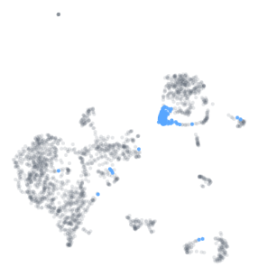

15

### Plasma Cell

JCHAIN-positive, immunoglobulin lambda light chain-secreting plasma cell with extensive ER machinery, high XBP1 and IRF4 expression, characteristic of antibody-secreting cells

Confidence: High

CELL ONTOLOGY TERM

[plasma cell (CL_0000786)](http://purl.obolibrary.org/obo/CL_0000786)

CELL STATE antibody-secreting

ORIGINAL LABEL 14

FUNCTIONALLY SIMILAR TO

B Cell (8)

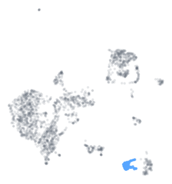

16

### Natural Killer Cell

CD94-like+NCR3-like+TIGIT+ natural killer cell with regeneration-associated phenotype

Confidence: Moderate

⚠ HETEROGENEOUS

CELL ONTOLOGY TERM

[mature natural killer cell (CL_0000824)](http://purl.obolibrary.org/obo/CL_0000824)

CELL STATE immature/regeneration-associated

ORIGINAL LABEL 15

DEVELOPMENTALLY RELATED TO

Neutrophil-Like Granulocyte (differentiates_to)Macrophage (differentiates_to)Macrophage (differentiates_to)

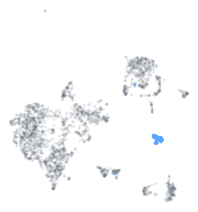

17

### Mast Cell

GATA3-positive, FCER1G-expressing, RTBDN-high mast cell with mast cell protease 1A-like expression and leukotriene synthesis machinery

Confidence: High

⚠ HETEROGENEOUS

CELL ONTOLOGY TERM

[mast cell (CL_0000097)](http://purl.obolibrary.org/obo/CL_0000097)

CELL STATE tissue-resident

ORIGINAL LABEL 16

FUNCTIONALLY SIMILAR TO

Granulocyte (11)

DEVELOPMENTALLY RELATED TO

Natural Killer Cell (differentiates_from)

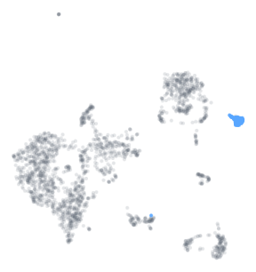

18

### Osteoclast

CTSK-positive, MMP9-expressing, ATP6V1B2-driven bone-resorbing osteoclast with active matrix degradation and lysosomal function

Confidence: Moderate

⚠ HETEROGENEOUS

CELL ONTOLOGY TERM

[osteoclast (CL_0000092)](http://purl.obolibrary.org/obo/CL_0000092)

CELL STATE terminally differentiated, metabolically active

ORIGINAL LABEL 17

FUNCTIONALLY SIMILAR TO

Neutrophil-Like Granulocyte (1)Macrophage (3)Macrophage (4)

DEVELOPMENTALLY RELATED TO

Natural Killer Cell (differentiates_from)

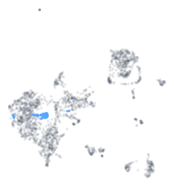

19

### CD8+ T Cell

CD8+ αβ T cell with exhausted/regulatory phenotype expressing PDCD1, HAVCR2, TOX, and lacking classical TCR constant chains

Confidence: High

CELL ONTOLOGY TERM

[CD8-positive, alpha-beta regulatory T cell (CL_0000795)](http://purl.obolibrary.org/obo/CL_0000795)

CELL STATE Exhausted/Regulatory

ORIGINAL LABEL 18

FUNCTIONALLY SIMILAR TO

T Cell (2)Naive T Cell (12)NK-like T Cell (13)

DEVELOPMENTALLY RELATED TO

Proliferating Thymocyte (differentiates_from)

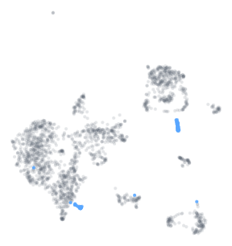

20

### Fibroblast

FBN2+ ECM-producing fibroblast with chondrogenic potential in limb blastema

Confidence: Moderate

CELL ONTOLOGY TERM

[skeletal muscle fibroblast (CL_0011027)](http://purl.obolibrary.org/obo/CL_0011027)

CELL STATE activated, ECM-producing, regeneration-associated

ORIGINAL LABEL 19

FUNCTIONALLY SIMILAR TO

Fibroblast (5)

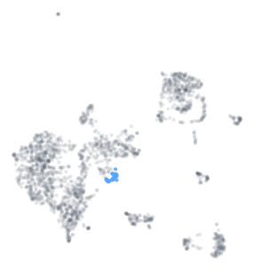

21

### Perforin+ Cytotoxic Cell

PRG3-positive, perforin-expressing cytotoxic cell with surfactant protein B expression and proliferative features

Confidence: High

⚠ HETEROGENEOUS

CELL ONTOLOGY TERM

[cytotoxic T cell (CL_0000910)](http://purl.obolibrary.org/obo/CL_0000910)

CELL STATE proliferating

ORIGINAL LABEL 20

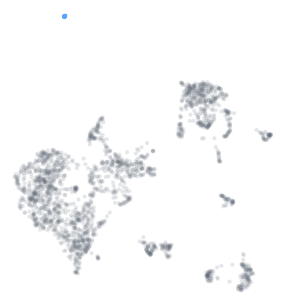